# 20210216_practice

Kinsey Reed

2/16/2021

**Creating Data**

```r
# randomly selecting coefficients for the intercept and slope coefficients
set.seed(10) # random number generator seed, for consistent results each run
betas <- rnorm(6)
betas # inspect data-generating values vs. what you estimate later
```

```
## [1]  0.01874617 -0.18425254 -1.37133055 -0.59916772  0.29454513  0.38979430
```

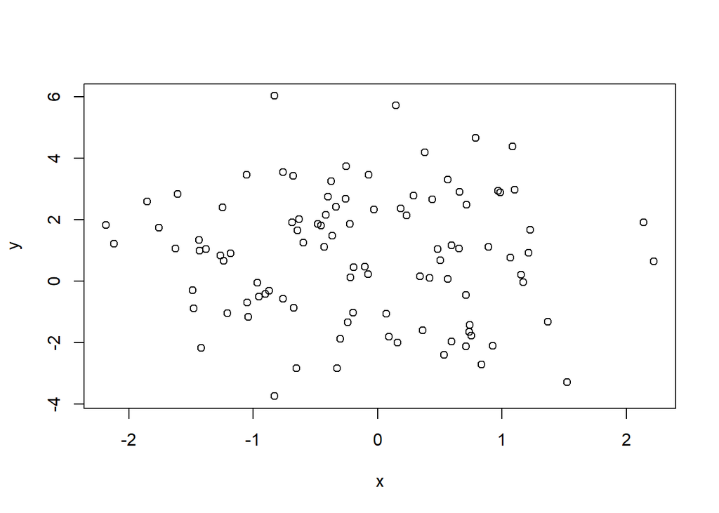

```r
# sample size
n <- 100
# variance of the residuals
s2 <- 3
# randomly selecting predictor variables
x1 <- rnorm(n) # continuous predictor
x2 <- rnorm(n) # continuous predictor
x3 <- sample(letters[1:3], n, T) # categorical predictor
# simulating observations
y <- betas[1] + betas[2] * x1 + betas[3] * x2 + betas[4] * x1 * x2 +
betas[5] * ifelse(x3 == 'b', 1, 0) + betas[6] * ifelse(x3 == 'c', 1, 0) +
rnorm(100, 0, sqrt(s2))
# plotting observations against x1, just for fun
plot(x = x1, y = y, ylab = 'y', xlab = 'x')
```

```r
# saving fake data
out <- data.frame(y = y, x1 = x1, x2 = x2, x3 = x3)
write.csv(out, 'Exam_1_Practice_Data.csv')
```

Importing dataset into R and inpecting the first several rows of data.

```r
data <- read.csv(file = 'Exam_1_Practice_Data.csv')

head(data)
```

```
##   X         y         x1         x2 x3
## 1 1 -1.039092 -1.2080762  0.6609867  c
## 2 2  1.483780 -0.3636760 -1.6580509  b
## 3 3  1.058827 -1.6266727  1.0281680  a
## 4 4  2.676566 -0.2564784  1.1279536  a
## 5 5  2.983615  1.1017795 -1.2801546  a
## 6 6 -1.774597  0.7557815  1.1288682  b
```

Fit a linear model that assumes your response is a function of x1, x2, and x3. Include an interaction between x1 and x2 only (i.e. do not include an interaction between your categorical variables and any other variables).

```r
fit <- lm(formula = y ~ x1 * x2 + x3, data = data)
summary(fit)
```

```
##
## Call:
## lm(formula = y ~ x1 * x2 + x3, data = data)
##
## Residuals:
##    Min     1Q Median     3Q    Max
## -4.288 -1.179 -0.221  1.231  3.924
##
## Coefficients:
##              Estimate Std. Error t value Pr(>|t|)
## (Intercept)  0.758088   0.276696   2.740  0.00736 **
## x1          -0.235987   0.190945  -1.236  0.21958
## x2          -1.111394   0.180166  -6.169 1.72e-08 ***
## x3b          0.007804   0.407237   0.019  0.98475
## x3c         -0.210479   0.455034  -0.463  0.64475
## x1:x2       -0.380193   0.192521  -1.975  0.05122 .
## ---
## Signif. codes:  0 '***' 0.001 '**' 0.01 '*' 0.05 '.' 0.1 ' ' 1
##
## Residual standard error: 1.758 on 94 degrees of freedom
## Multiple R-squared:  0.3073, Adjusted R-squared:  0.2705
## F-statistic: 8.342 on 5 and 94 DF,  p-value: 1.471e-06
```

3. Calculate residuals by hand (i.e., do not use the resid() function))

y^ = b0 + b1x1 + b2x2 + b3(x3b) + b4(x3c) + b5x1x2 residuals = observed (yi) - estimated (y^)

```r
data$b <- ifelse(data$x3 == 'b', 1, 0)
data$c <- ifelse(data$x3 == 'c', 1, 0)

b <- coef(fit)
b
```

```
##  (Intercept)           x1           x2          x3b          x3c        x1:x2
##  0.758087590 -0.235986737 -1.111393659  0.007803951 -0.210478885 -0.380192677
```

```r
new_y <- b[1] + b[2] * data$x1 + b[3] * data$x2 + b[4] * data$b + b[5] * data$c + b[6] * data$x1 * data$x2
residuals <- data$y - new_y
summary(residuals)
```

```
##    Min. 1st Qu.  Median    Mean 3rd Qu.    Max.
##  -4.288  -1.180  -0.221   0.000   1.231   3.924
```

Interpret the effect of variable x2 when x1 = -1 y^ = b0 + b1x1 + b2x2 + b3x3b + b4x3c + b5x1x2 #collect terms associated with x2

y = b0 + b1x1 +x2(b2 + b5x1) +b3(x3b) + b4(x3c) one unit change in x2 is equal to its slope, or b2 + b5x1

```r
b[3]+ b[6] * -1
```

```
##        x2
## -0.731201
```

5. Interpret the effect of variable x2 when x1 = 1

```r
b[3] + b[6] * 1
```

```
##        x2
## -1.491586
```

6. Plot predicted y against the observed range of x2. Assume level ‘a’ of your categorical variable and fix x1 at its mean.

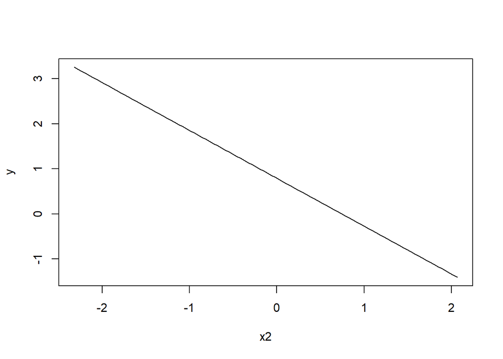

```r
x2_range <- seq(min(data$x2), max(data$x2), length.out = 100)
y_pred <- b[1] + b[2] * mean(data$x1) + b[3] * x2_range + b[6] * mean(data$x1) * x2_range
plot(x = x2_range, y = y_pred, type = 'l', xlab = 'x2', ylab = 'y')
```

7. Interpret the effect of variable x3

= slope coefficients x3b and x3c The difference in y (when all other variables held constant) between category b and a is 0.007804

the difference in y (when all other variables held constant) between category c and a is -0.210479

8. Describe how R codes the categorical variable x3. Demonstrate by reporting the first 5 values of variables derived from x3

R creates k − 1 dummy variables, where k is the number of levels of your categorical variable. So here, R would create 2 dummy variables. A is set aside as the reference, so there is a dummy variable associated with variable b that equals 1 if a factor level is b and equals 0 otherwise. Similarly, there is another variable c that equals 1 if a factor level is c and equals 0 otherwise.

```r
cbind(data$x3[1:5],
      ifelse(data$x3 == 'b', 1, 0)[1:5],
      ifelse(data$x3 == 'c', 1, 0)[1:5])
```

```
##      [,1] [,2] [,3]
## [1,] "c"  "0"  "1"
## [2,] "b"  "1"  "0"
## [3,] "a"  "0"  "0"
## [4,] "a"  "0"  "0"
## [5,] "a"  "0"  "0"
```

Derive the test statistic and p-value associated with variable x2. What is the null hypothesis assumed by the lm() function? Do we reject or fail to reject this null hypothesis?

```r
#test statistic
ts <- coef(fit)[3] / summary(fit)[['coefficients']][3, 2]
ts; summary(fit)[['coefficients']][3, 3] #semicolon means new line
```

```
##        x2
## -6.168704
```

```
## [1] -6.168704
```

```r
#p value
pt(ts, df = nrow(data) - length(coef(fit))) * 2 #df is n - # of coefficients
```

```
##           x2
## 1.720716e-08
```

The null hypothesis is the slope coefficient associated with the variable x2 = 0. We reject the null hypothesis because the p value is smaller than any reasonable $\alpha$

1. Be sure to play around with probability density functions we learned in class. E.G., assume you obtain the following realizations of random variable Y : y = (2.4, 5.2, 1.7), assume y are Gaussian distributed with mean = 2 and standard deviation = 3. Calculate the probability density of each of your three realizations.

```r
y <- c(2.4, 5.2, 1.7)
dnorm(y, 2, 3)
```

```
## [1] 0.13180395 0.07528761 0.13231752
```